# Impacto del transporte entre la residencia del alumno y la universidad en su tiempo efectivo de trabajo y rendimiento académico

**4. Calificación del Transporte en función del Tiempo de Transporte semanal** Para realizar regresión sobre la variable calificación del transporte se aclara que este modelo funciona tomando la escala con la que se trabajo en el proyecto: 1(malo)-10(bueno), por lo que la variable calificación del transporte solo podría asumir valores enteros en este rango.

```r
Trans_Calif=lm(DF$Calificacion~DF$Transporte_Semanal)
summary(Trans_Calif)
```

```
##
## Call:
## lm(formula = DF$Calificacion ~ DF$Transporte_Semanal)
##
## Residuals:
##     Min      1Q  Median      3Q     Max
## -5.9840 -0.9365  0.1790  1.3831  4.0128
##
## Coefficients:
##                         Estimate Std. Error t value Pr(>|t|)
## (Intercept)            8.3130122  0.2434415  34.148  < 2e-16 ***
## DF$Transporte_Semanal -0.0033226  0.0003825  -8.688 2.35e-15 ***
## ---
## Signif. codes:  0 '***' 0.001 '**' 0.01 '*' 0.05 '.' 0.1 ' ' 1
##
## Residual standard error: 1.855 on 178 degrees of freedom
## Multiple R-squared:  0.2978, Adjusted R-squared:  0.2938
## F-statistic: 75.48 on 1 and 178 DF,  p-value: 2.349e-15
```

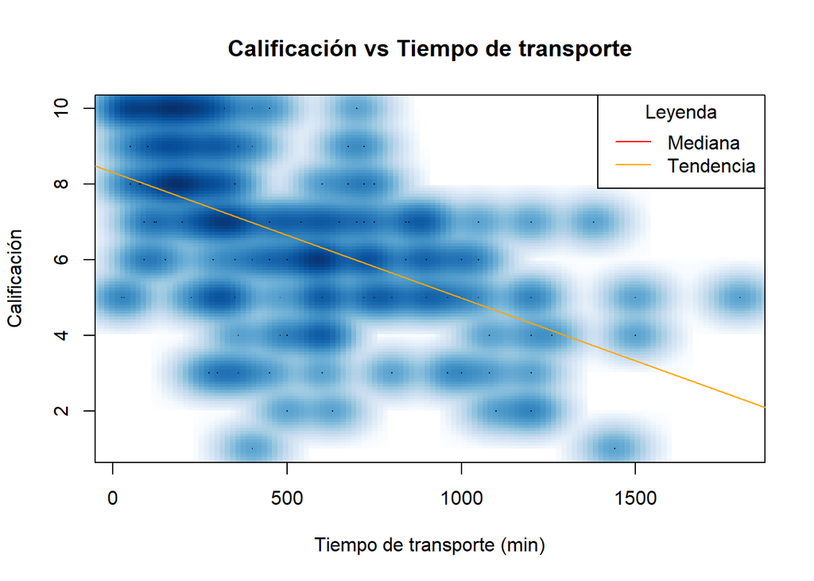

```r
smoothScatter(DF$Transporte_Semanal,DF$Calificacion,xlab= "Tiempo de transporte (min)",ylab="Calificación",main="Calificación vs Tiempo de transporte")
abline(h=median(DF$Transporte_Semanal),col="red")
abline(Trans_Calif, col='orange')
legend("topright", c("Mediana", "Tendencia"),lty=c(1, 1), col=c("red","orange"),title="Leyenda",bg="white")
```

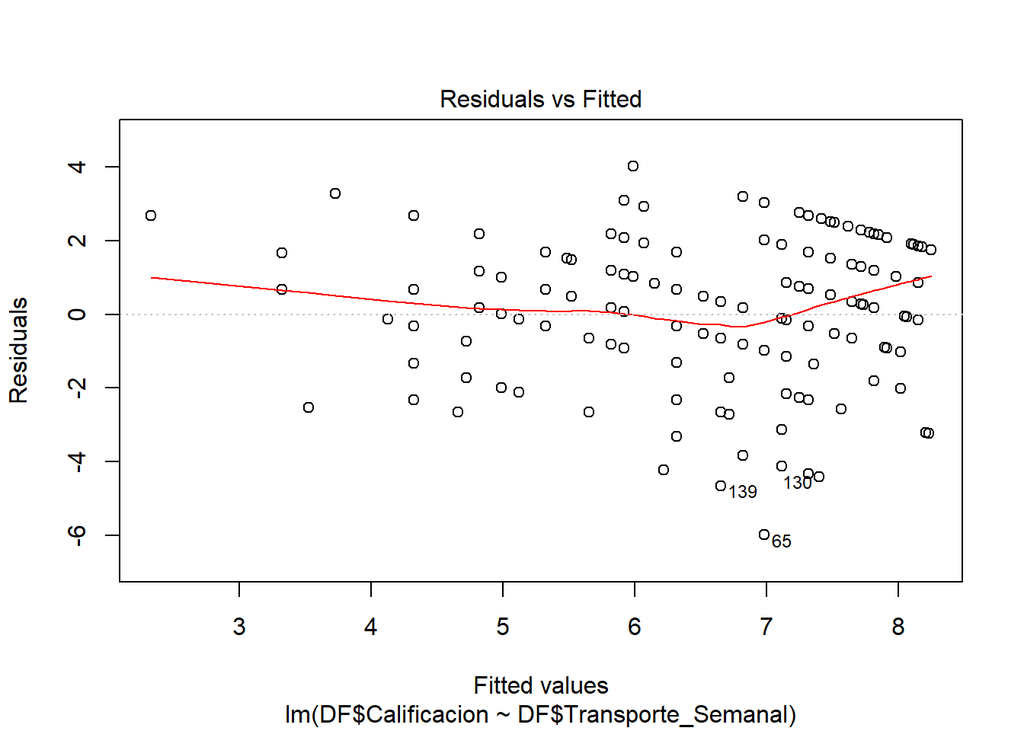

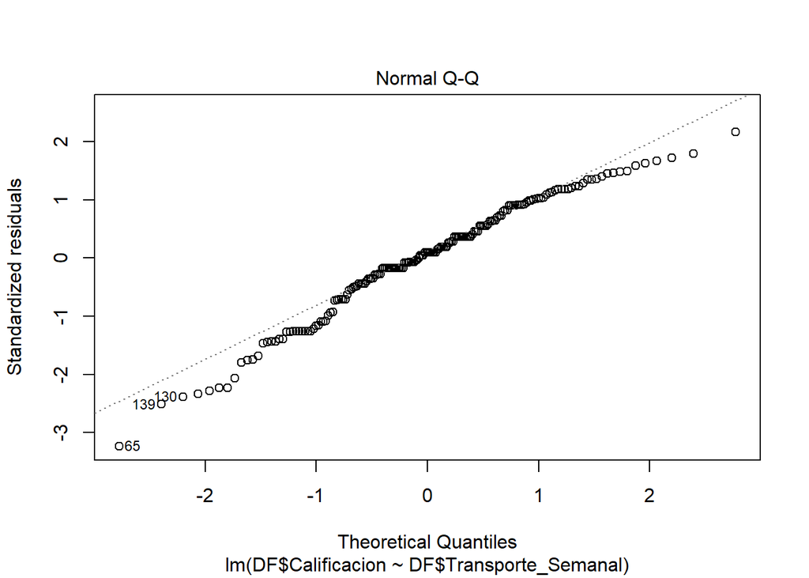

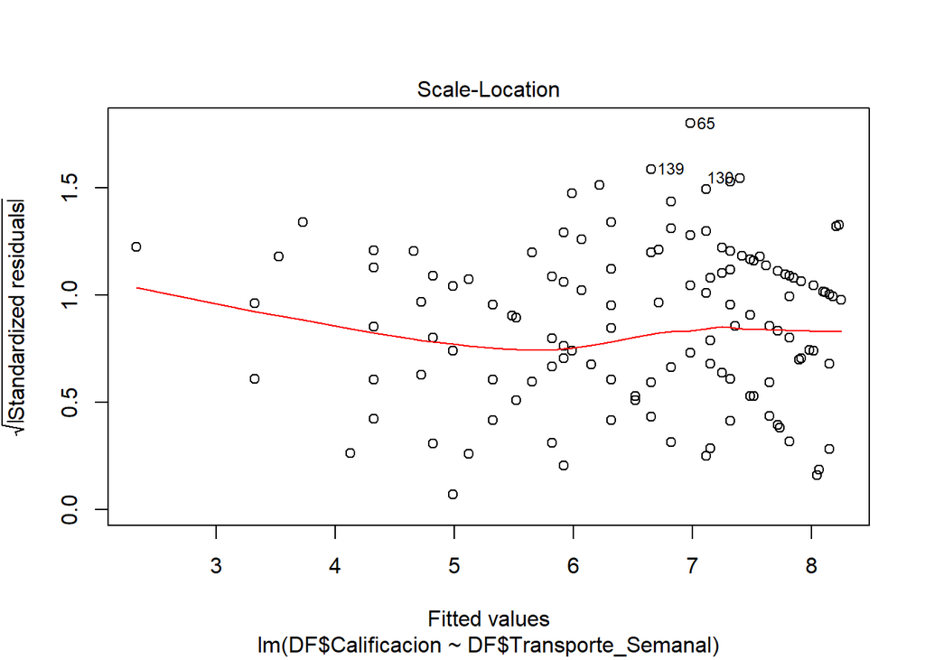

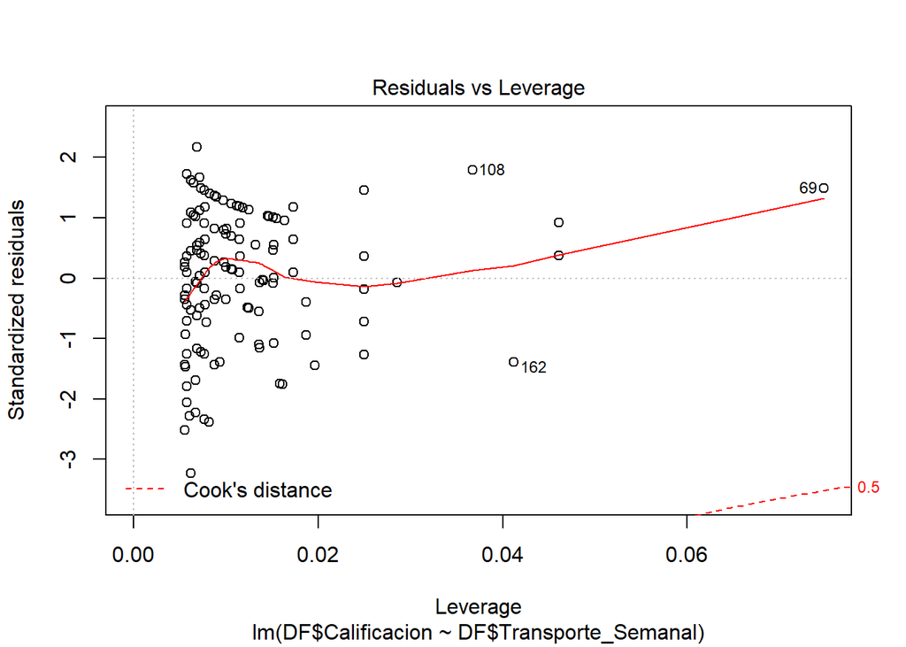

```r
plot(Trans_Calif)
```

**Análisis** Al analizar el modelo obtenido se observa un p.value igual a 2.349e-15, por lo que al ser menor a la significancia se rechaza la hipótesis nula, la cual era la no dependencia de la variable.

Asimismo, al observar el gráfico de los residuos del modelo se observa heterocedasticidad y en el gráfico de la normal se observan los valores muy dispersos de la tendencia que deberían seguir por lo que se concluye que el modelo no es adecuado para realizar inferencia sobre la variable.

**5. Calificación en función del Tiempo de Transporte Semanal y el principal Medio de Transporte** Para realizar regresión sobre la variable calificación del transporte se aclara que este modelo funciona tomando la escala con la que se trabajo en el proyecto: 1(malo)-10(bueno), por lo que la variable calificación del transporte solo podría asumir valores enteros en este rango.

```r
R_Calif1=lm(DF$Calificacion~DF$Transporte_Semanal+DF$M1)
summary(R_Calif1)
```

```
##
## Call:
## lm(formula = DF$Calificacion ~ DF$Transporte_Semanal + DF$M1)
##
## Residuals:
##    Min     1Q Median     3Q    Max
## -6.293 -1.070  0.202  1.169  3.701
##
## Coefficients:
##                                      Estimate Std. Error t value Pr(>|t|)
## (Intercept)                         9.5057764  0.5132635  18.520  < 2e-16 ***
## DF$Transporte_Semanal              -0.0024889  0.0004365  -5.701 5.11e-08 ***
## DF$M1Carro Particular              -1.2166960  0.5790292  -2.101  0.03708 *
## DF$M1Combi / micro                 -2.5266152  0.6035355  -4.186 4.53e-05 ***
## DF$M1Metropolitano / Corredor rojo -2.0044517  0.6688324  -2.997  0.00313 **
## DF$M1Otro                           0.5440012  1.8388302   0.296  0.76771
## DF$M1Taxi                          -1.1674206  0.6390912  -1.827  0.06949 .
## DF$M1Tren electrico                -1.6131165  1.0449319  -1.544  0.12450
## DF$M1Voy caminando                 -1.2410374  0.8831574  -1.405  0.16177
## ---
## Signif. codes:  0 '***' 0.001 '**' 0.01 '*' 0.05 '.' 0.1 ' ' 1
##
## Residual standard error: 1.766 on 171 degrees of freedom
## Multiple R-squared:  0.3884, Adjusted R-squared:  0.3598
## F-statistic: 13.58 on 8 and 171 DF,  p-value: 3.804e-15
```

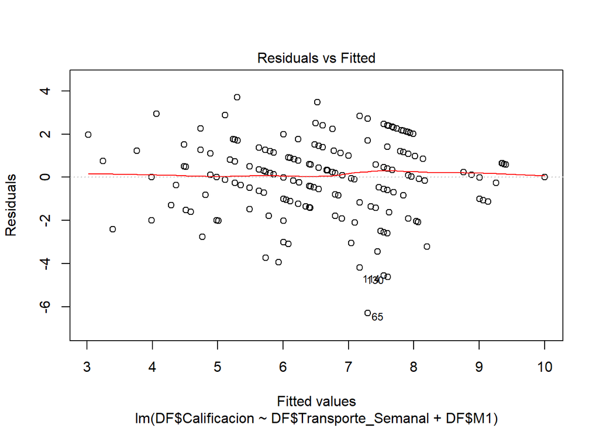

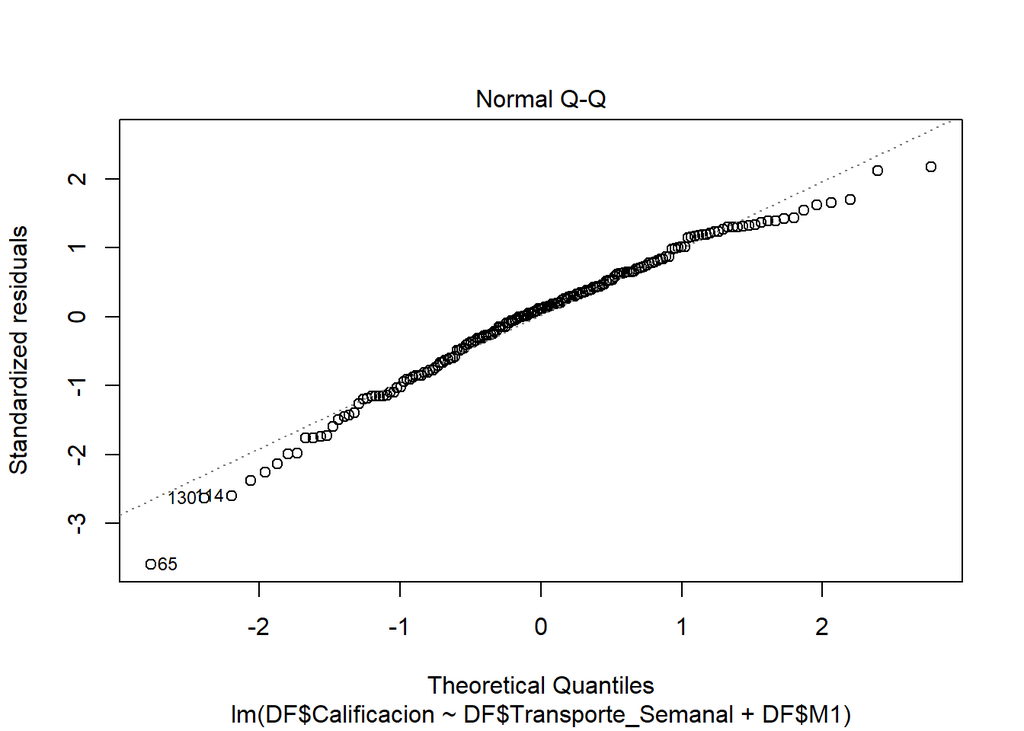

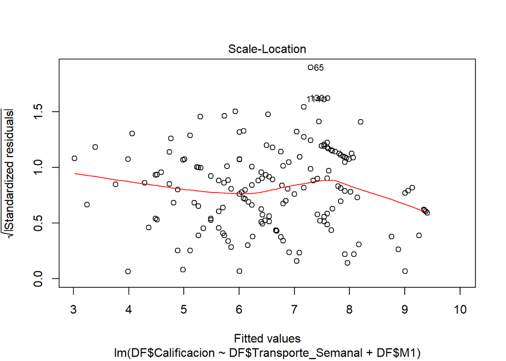

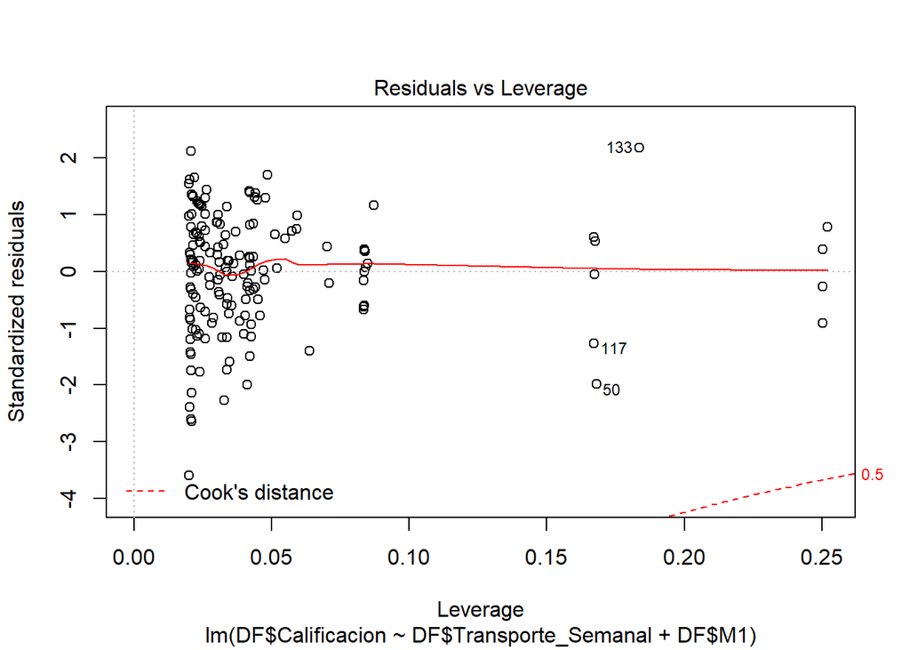

```r
plot(R_Calif1)
```

**Análisis** Al analizar el modelo obtenido se observa un p.value igual a 3.804e-15, por lo que al ser menor a la significancia se rechaza la hipótesis nula, la cual era la no dependencia de la variable.

Asimismo, en el gráfico de residuos del modelo se puede observar heterocedasticidad en los residuos por lo que se concluye que el modelo no es adecuado para realizar inferencia sobre la variable.

### CONCLUSIONES:

En el presente trabajo tenía como objetivo analizar la relación del tiempo de transporte de los estudiantes hacia la universidad con distintos aspectos de la vida de los mismos como nivel de estrés, horas de sueño diarias o número de cursos desaprobados en el último ciclo de la universidad. Estas posibles relaciones se analizaron mediante el planteamiento de preguntas que fueron respondidas desde el punto de vista estadístisco obteniéndose las siguientes conclusiones:

De acuerdo al análisis descriptivo, se obtuvo que el tiempo de transporte promedio de los estudiantes en UTEC es de 51.81 minutos con una mediana de 7 en la calificación del mismo, lo cual puede traducirse como una experiencia de transporte buena por parte del alumno. Asimismo el medio de transporte más utilizado por los alumnos de la UTEC es el microbús, seguido por el uso de un carro particular.

De acuerdo a las pruebas de hipótesis realizadas para un nivel de significancia de 0.05 se encontraron relaciones entre algunas variables, siendo las más robustas e importantes para el estudio las siguientes: -La relación existente entre la calificación de la experiencia del transporte y el tiempo semanal del mismo: Donde la calificación disminuiría cuando el tiempo de transporte aumenta, lo cual podría explicarse puesto que un mayor tiempo de transporte suele generar una mayor incomodidad en el estudiante.

-La relación existente entre horas de sueño diarias y el tiempo semanal de transporte: Donde las horas de sueño disminuirían cuando aumenta el tiempo de transporte, lo cual podría explicarse ya que el tiempo requerido para una actividad se utilizaría en la otra.

De acuerdo a los modelos obtenidos por regresión, no se encontró ninguno que sea lo suficientemente robusto como para realizar inferencia o predicción sobre alguna variable debido principalmente a la heterocedasticidad en los residuos de estos y a la falta de una distribución normal en sus residuos estandarizados.

### Bibliografía:

- https://gestion.pe/tendencias/lima-ciudades-peor-trafico-269483-noticia/
- https://amp.milenio.com/especiales/estres-cronico-como-identificarlo